# Lab 05

STA 198 Summer 2020 (Jiang)

Today’s lab will explore what to do when you have a merge conflict with others, which may have seen already through the course of your collaboration last week in Lab 04. Additionally, you will work with your *team* to create a spatial visualization using *simple features* and map data.

**Do not configure Git until the team-based section.**

# Visualizing spatial data

**On your own**: Follow along with the code and results presented in the following section. This portion will not be graded; it is only for you to familiarize yourself with the basics of spatial data visualization (no need to select a specific GitHub repository to create an RStudio Cloud project from).

## Packages

Run the following code to load the needed packages. You may need to `install.packages()` them first; note that they’re both pretty big, so if you need to install them, it may take a bit:

```r
library(tidyverse)
library(sf)
```

We will use the `sf` package, which stands for **simple features**. Simple features are a commonly-used spatial data standard that specify storage and access for map geometrics used by geographic information systems (GIS). The `sf` package in `R` represents simple features in a tidy way, in which each row standards for a simple feature, and each column corresponds to a variable.

Simple features use 2D geometries which “connect the dots” between defined points in space:

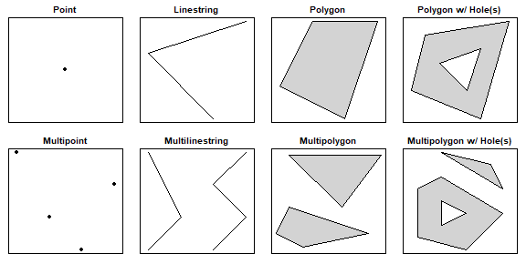

## Reading in data

To read simple features from a file or database, use the `st_read()` function. There are already some objects included in the `sf` package. We will load a file that corresponds to the counties in North Carolina:

```r
library(sf)
nc <- st_read(system.file("shape/nc.shp", package = "sf"), quiet = TRUE)
nc
```

```
## Simple feature collection with 100 features and 14 fields
## geometry type:  MULTIPOLYGON
## dimension:      XY
## bbox:           xmin: -84.32385 ymin: 33.88199 xmax: -75.45698 ymax: 36.58965
## geographic CRS: NAD27
## First 10 features:
##     AREA PERIMETER CNTY_ CNTY_ID        NAME  FIPS FIPSNO CRESS_ID BIR74 SID74
## 1  0.114     1.442  1825    1825        Ashe 37009  37009        5  1091     1
## 2  0.061     1.231  1827    1827   Alleghany 37005  37005        3   487     0
## 3  0.143     1.630  1828    1828       Surry 37171  37171       86  3188     5
## 4  0.070     2.968  1831    1831   Currituck 37053  37053       27   508     1
## 5  0.153     2.206  1832    1832 Northampton 37131  37131       66  1421     9
## 6  0.097     1.670  1833    1833    Hertford 37091  37091       46  1452     7
## 7  0.062     1.547  1834    1834      Camden 37029  37029       15   286     0
## 8  0.091     1.284  1835    1835       Gates 37073  37073       37   420     0
## 9  0.118     1.421  1836    1836      Warren 37185  37185       93   968     4
## 10 0.124     1.428  1837    1837      Stokes 37169  37169       85  1612     1
##    NWBIR74 BIR79 SID79 NWBIR79                       geometry
## 1       10  1364     0      19 MULTIPOLYGON (((-81.47276 3...
## 2       10   542     3      12 MULTIPOLYGON (((-81.23989 3...
## 3      208  3616     6     260 MULTIPOLYGON (((-80.45634 3...
## 4      123   830     2     145 MULTIPOLYGON (((-76.00897 3...
## 5     1066  1606     3    1197 MULTIPOLYGON (((-77.21767 3...
## 6      954  1838     5    1237 MULTIPOLYGON (((-76.74506 3...
## 7      115   350     2     139 MULTIPOLYGON (((-76.00897 3...
## 8      254   594     2     371 MULTIPOLYGON (((-76.56251 3...
## 9      748  1190     2     844 MULTIPOLYGON (((-78.30876 3...
## 10     160  2038     5     176 MULTIPOLYGON (((-80.02567 3...
```

Other than these metadata, we have a tidy dataset as we’re used to, except the last column is a geometry.

## SIDS

The dataset from today examines Sudden Infant Death Syndrome (SIDS) in each county in North Carolina. SIDS is an unexplained death of an apparently healthy infant, often occurring during sleep. We will create a basic visualization that maps the number of SIDS cases to each county. A few of the variables in the dataset are as follows:

- NAME: The county name
- FIPS/FIPSNO: The FIPS code of the county (a five digit Federal Information Processing Standards code that uniquely identifies US counties)
- BIR74: The number of births in 1974
- SID74: The number of SIDS cases in 1974
- NWBIR74: The number of non-white births in 1974
- BIR79, SID79, NWBIR79: similarly for 1979

## Creating plots

Now let’s create a basic plot using the `nc` object! `sf` objects work well with the tidyverse. For instance, try the following code, noting that we did not specify any aesthetic mapping:

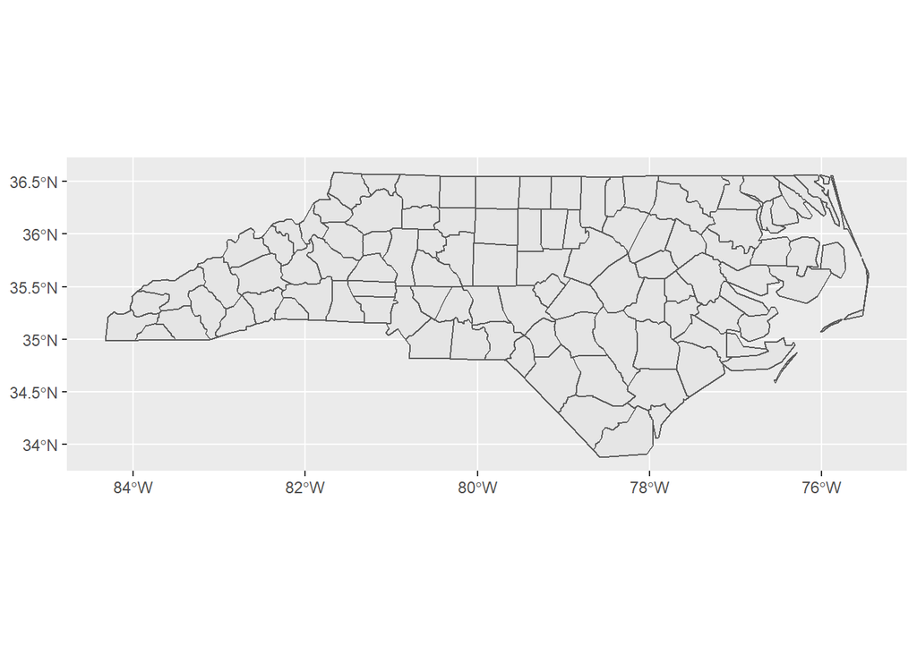

```r
ggplot(data = nc) +
  geom_sf()
```

We can also add some global plot options:

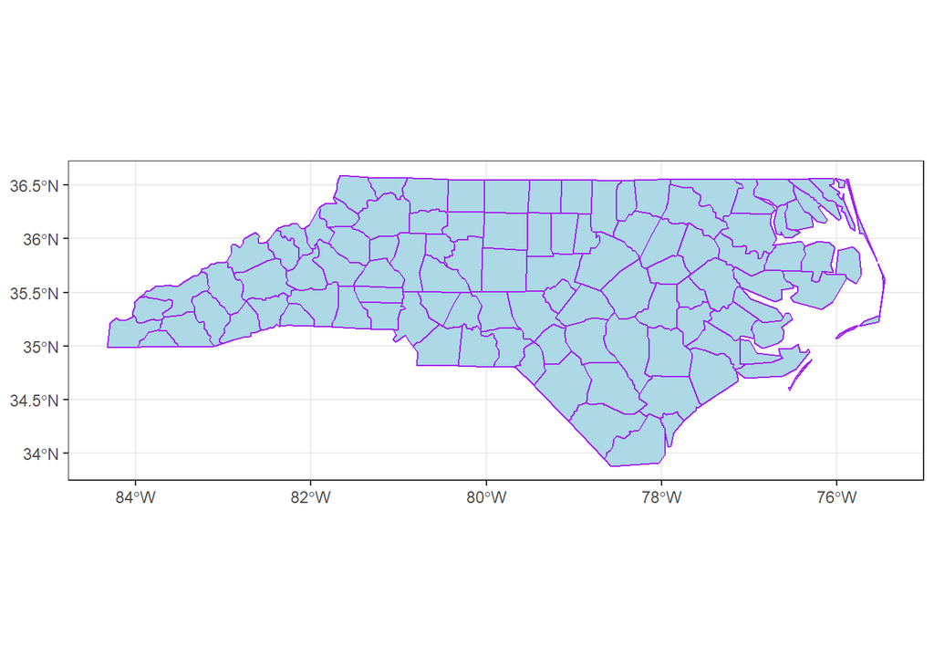

```r
ggplot(data = nc) +
  geom_sf(color = "purple", fill = "lightblue") +
  theme_bw()
```

Remember that in our dataset, we had some data that corresponded to each county. How might we incorporate them into our plot? We need to set an aesthetic mapping. **Importantly**: for `sf` geometries, the aesthetic mapping is done in the `geom_sf()` layer.

Let’s create a **choropleth map** that displays the number of births in 1974 for each county. Note how the following code is different from the earlier code:

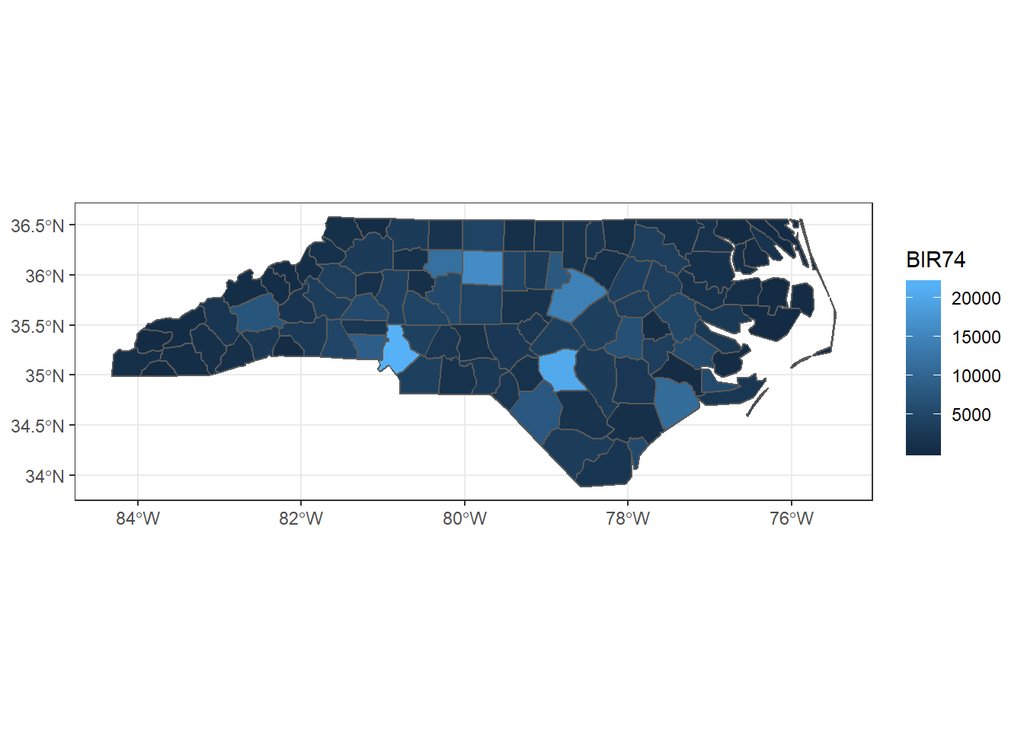

```r
ggplot(data = nc) +
  geom_sf(aes(fill = BIR74)) +
  theme_bw()
```

We can also manually set the color scheme by adding a `scale_fill_gradient()` layer. Here, we’ll specify hex values for our color extremes:

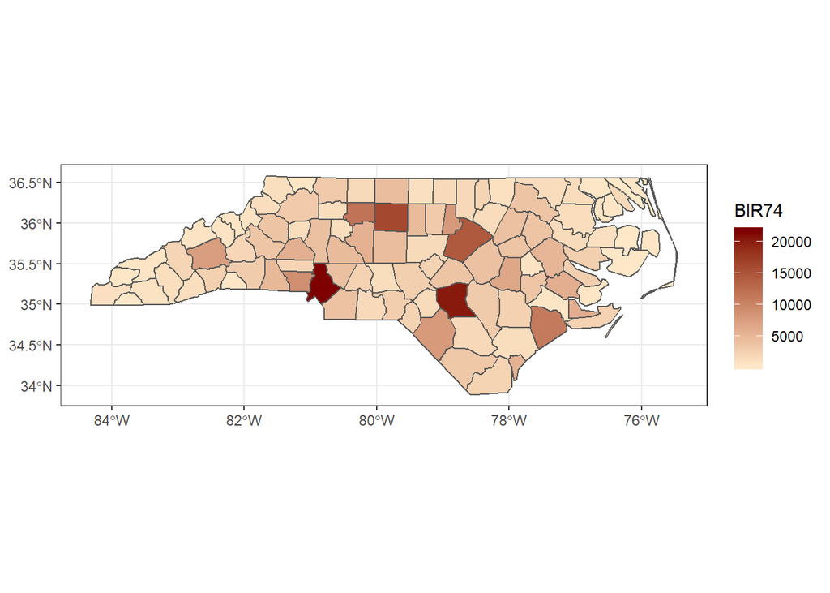

```r
ggplot(nc) +
  geom_sf(aes(fill = BIR74)) +
  scale_fill_gradient(low = "#fee8c8", high ="#7f0000") +
  theme_bw()
```

## dplyr() with simple features

```r
nc %>%
  filter(BIR74 > 10000) %>%
  select(NAME, BIR74)
```

```
## Simple feature collection with 6 features and 2 fields
## geometry type:  MULTIPOLYGON
## dimension:      XY
## bbox:           xmin: -81.06555 ymin: 34.45701 xmax: -77.12939 ymax: 36.25709
## geographic CRS: NAD27
##          NAME BIR74                       geometry
## 1     Forsyth 11858 MULTIPOLYGON (((-80.0381 36...
## 2    Guilford 16184 MULTIPOLYGON (((-79.53782 3...
## 3        Wake 14484 MULTIPOLYGON (((-78.92107 3...
## 4 Mecklenburg 21588 MULTIPOLYGON (((-81.0493 35...
## 5  Cumberland 20366 MULTIPOLYGON (((-78.49929 3...
## 6      Onslow 11158 MULTIPOLYGON (((-77.53864 3...
```

Notice that the geometry is **“sticky”**: the geoemtry and metadata associated with it are still carried with the dataset, even though we didn’t select for it. In order to remove the geometry, include the function `st_drop_geometry()` in your pipeline:

```r
nc %>%
  filter(BIR74 > 10000) %>%
  select(NAME, BIR74) %>%
  st_drop_geometry()
```

```
##          NAME BIR74
## 1     Forsyth 11858
## 2    Guilford 16184
## 3        Wake 14484
## 4 Mecklenburg 21588
## 5  Cumberland 20366
## 6      Onslow 11158
```

# Merge conflicts (uh oh)

When two collaborators make changes to a file and push the file to their repository at the same time (i.e., without pulling), git merges these two files as illustrated below:

[figure not shown]

If these two files have conflicting content on the same line, git will produce a **merge conflict**. Merge conflicts nede to be resolved manually, as they require human intervention:

[figure not shown]

To resolve the merge conflict, decide if you want to keep only your text, the text on GitHub, or incorporate changes from both texts. Delete the conflict markers `<<<<<<<`, `=======`, `>>>>>>>` and make the changes you want in the final merge:

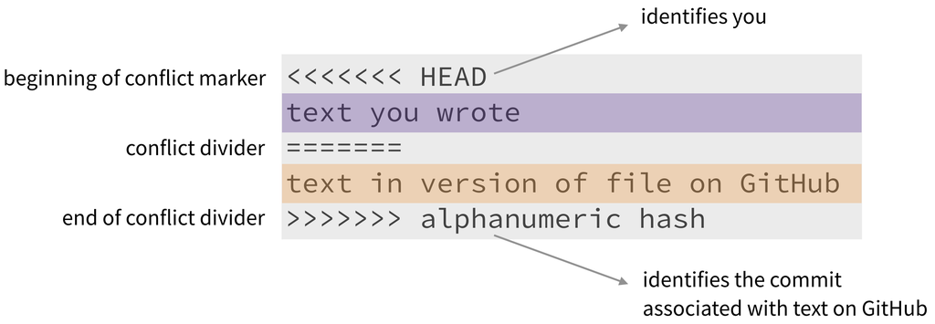

# Resolving a merge conflict

Team repositories have already been created for you with the prefix `lab-05-`. This assignment is due **June 30** at 11:59p.

[Your team repository may be found here.](https://github.com/sta198-su20)

**Assign numbers 1, 2, 3, and 4 to each of your team members** (if only 3 team members, just number 1 through 3). Carefully go through the following exercises as a group **in order**, which simulate a merge conflict. **Correctly completing this exercise will be worth 15 points on this week’s lab grade.**

**Member 2 only: pull the repository** and review the document with the merge conflict. A merge conflict occurred because you edited the same part of the document as Member 1. Resolve the conflict by choosing to keep your real team name, then knit, stage, commit and push again. **Discuss the error with your teammates.**

4. **3 points. Member 3**: Do not pull the changes from Members 1 or 2. Write some narrative in the space provided for Exercise 6 (it doesn’t matter what you write, just write something!), then knit, commit, and push.

**You also should have gotten an error.** A merge conflict should have occurred with the header of the document, since now it no longer matches the commit you made to the team name. However, this time, no merge conflicts should occur *with Exercise 6*, since this is a different part of the document from Members 1 and 2. **Discuss the error with your teammates.**

**Member 3 only: pull the repository**, and finally, knit, commit, and push your changes.

5. **0 points. Everyone**: Pull the latest repository. Now you should all be synced up.
6. **6 points. Member 4** (if no member 4, then choose another group member to complete this): describe the two errors your team encountered in exercises 3 and 4. What were the similarities between these two errors? What made the error from exercise 3 different from that of exercise 4 in terms of what you might have expected?

# More maps!

We will be using the `nc` dataset again, as loaded from the `sf()` package. In your team repository, read in the dataset as you did on the guided individual portion.

**Every member** must make at least one meaningful commit to Exercises 7 - 10; failure to do so may result in up to 5 points taken off the assignment.

7. **5 points** Create a map that plots the number of SIDS cases by NC county in 1979. Why is this a misleading plot?
8. **7 points** Now create a map that plots the SIDS *rate* by NC county in 1979 (the number of cases / population).
9. **8 points** Finally, create a map that plots the difference in SIDS rate by NC county from 1974 to 1979. Create a table that lists the top five “most-improved” counties based on the difference in SIDS rate from 1974 to 1979, being sure to drop the associated geometry from your table.
10. **15 points** If you were a health data scientist working for the state of NC in 1980, which counties would you focus on regarding SIDS (knowing that public health funds are very limited!)? Explain, using any graphs or tables as needed.